# LDA-method-and-Softmax-Ridge-Regression-with-Radial-Based-Functions-in-R

Mikołaj Ozimek

2024-02-08

Initial data check.

Let’s check if there are any non-numeric or unknown values in the data.

We do not need to correct the data (No imputation required).

```
## [1] 0
```

Let’s see if the data requires scaling (if there are any outliers).

```
## [1] 0
```

Let’s see what the types of individual variables are.

```
##      A         B         Class
## [1,] "numeric" "numeric" "integer"
```

```
## [1] "factor"
```

Only the type of the dependent variable had to be changed to factor.

Classification using the LDA algorithm.

We will see a preliminary data graph.

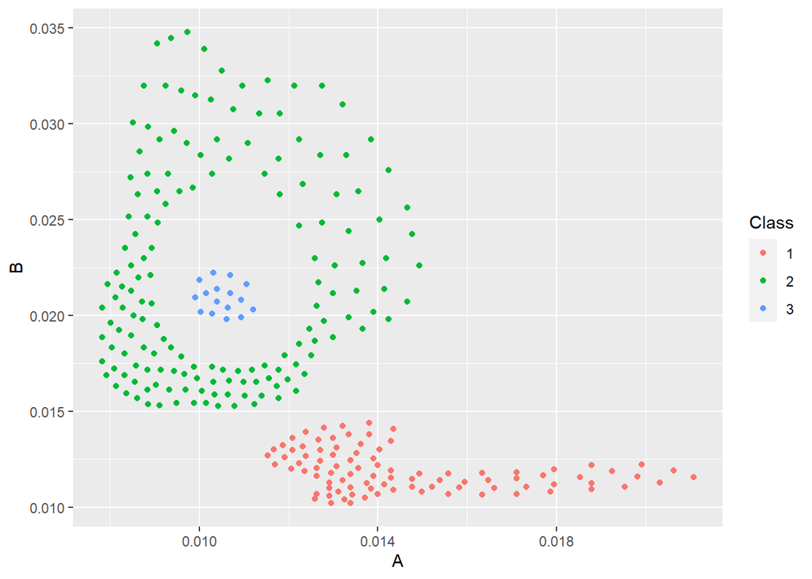

The decision variable takes 3 values, which, as can be seen in the chart, are not linearly separable. Let’s see if we can separate the observations using two canonical variables.

Let’s create a new data frame to graph the new variables

```
##     zm_kan1   zm_kan2 Class
## 1 -1.957068 0.6989997     1
## 2 -1.812319 0.8514414     1
## 3 -1.655686 0.9525571     1
## 4 -1.623739 0.9016658     1
```

In the LDA method, we project our observations relative to canonical vectors in order to increase the distance between the centers of individual classes and reduce the variance within classes. If the data is better separated from each other, the classifier will perform better, making fewer errors..

Let’s see the classification graph after running the algorithm

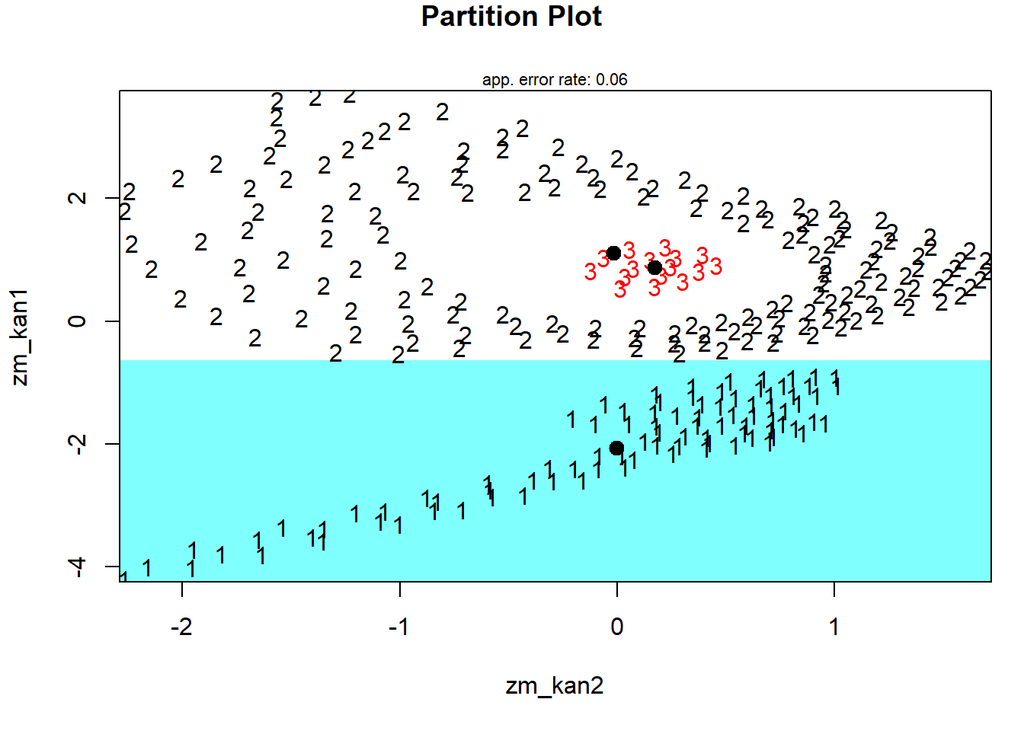

Points on the graph are not linearly separable. Projecting observations to a new space did not help. This is because the canonical variables are a linear combination of the original variables and not a linear function of them. We are talking here in particular about points from class 3, which are surrounded by points from class 2, which cannot be separated by executing only an algorithm.

Let’s try to transform the observations from class 3 in order to increase the separability of the input data.

Any transformations such as square root, logarithm or power did not give the intended results.

Let’s see what the observations from variable 3 look like after multiplying by 1.5.

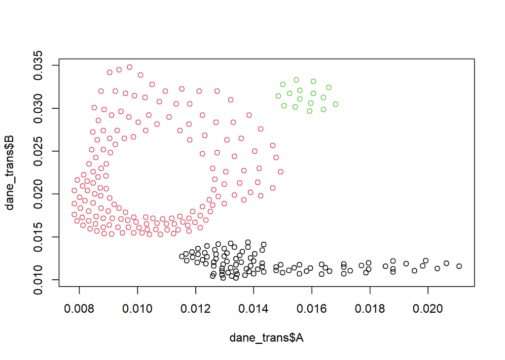

Let’s create the model again. Now we will apply the transformed data.

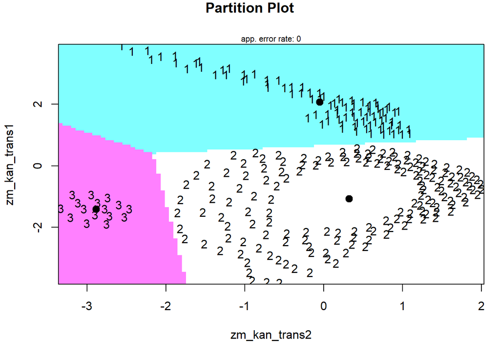

Let’s check how the model deals with new data. For this purpose, I will use n-fold and 10-fold cross-validation.

```
## Linear Discriminant Analysis
##
## 266 samples
##   2 predictor
##   3 classes: '1', '2', '3'
##
## No pre-processing
## Resampling: Leave-One-Out Cross-Validation
## Summary of sample sizes: 265, 265, 265, 265, 265, 265, ...
## Resampling results:
##
##   Accuracy  Kappa
##   1         1
```

Both the Accuracy Coefficient and the Kappa statistic were 1. This means that the classifier did not make a mistake even once.

```
## Linear Discriminant Analysis
##
## 266 samples
##   2 predictor
##   3 classes: '1', '2', '3'
##
## No pre-processing
## Resampling: Cross-Validated (10 fold)
## Summary of sample sizes: 240, 240, 238, 240, 239, 241, ...
## Resampling results:
##
##   Accuracy  Kappa
##   1         1
```

In the case of 10-fold cross-validation, we also obtained perfect classifiers..

Because the input data set was not linearly separable both at the beginning and after conversion to canonical variables, some transformation of the observations from class 3 was required. If we wanted to classify a new observation with an unknown value of the target variable, having the characteristics of observations from class 3 before the transformation, then we should also transform it for correct classification. Let me illustrate this with an example.

Let’s assume that the new observation has the given values of the independent variables: 0.010693628 and 0.02116404. Let’s mark it on the chart.

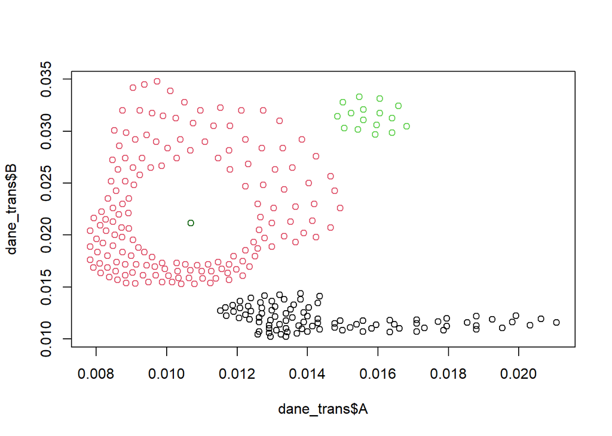

As you can see, it would be classified as class 2. After transformation 1.5, it should be in the correct class.

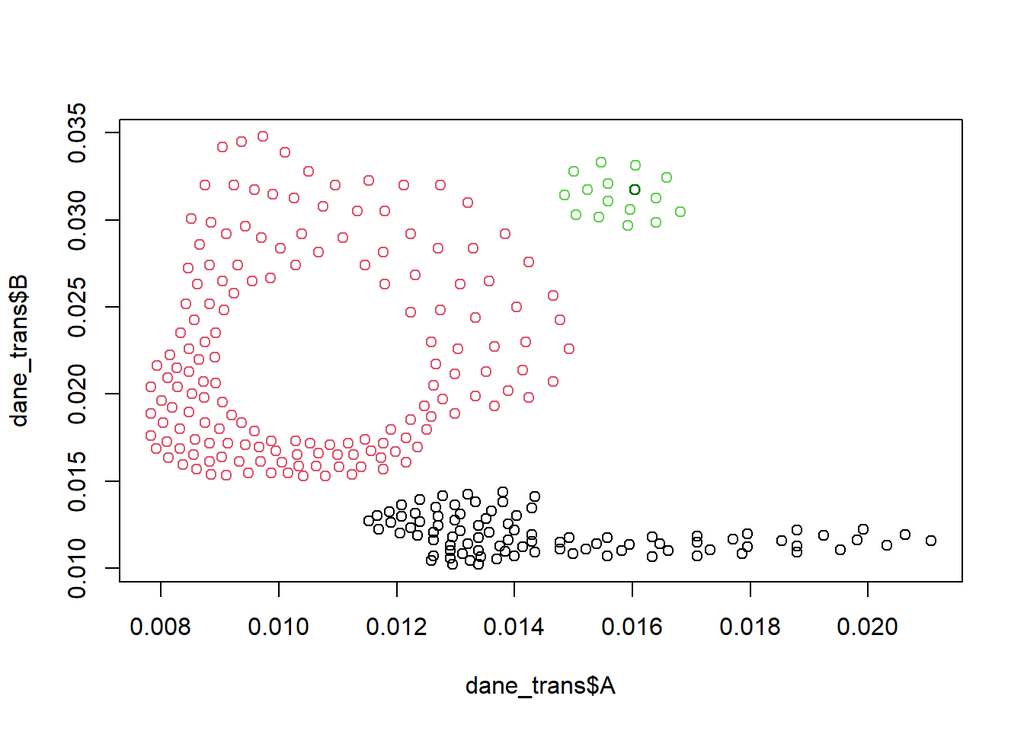

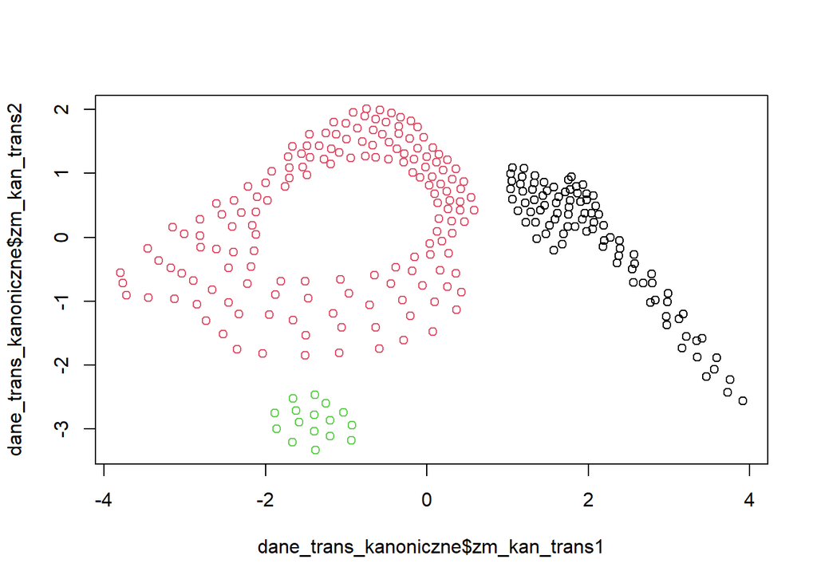

Observation classification chart for canonical variables.

Logistic regression model

Let’s do a simple logistic regression first.

```
##    predykcje
##       1   2   3
##   1  92   0   0
##   2   0 158   0
##   3   0   0  16
```

As in the case of LDA, in order to create decision areas, observations must be linearly separable. For this reason, I used transformed data. This is because of the decision boundary in the regression logistic there is a certain linear function. In this case, we are dealing with softmax regression, with 3 values of the decision variable, so there will be 2 linear functions as decision functions.

Let’s run a penalized logistic regression model.

```
## glmnet
##
## 266 samples
##   2 predictor
##   3 classes: '1', '2', '3'
##
## No pre-processing
## Resampling: Cross-Validated (10 fold)
## Summary of sample sizes: 239, 240, 240, 241, 239, 239, ...
## Resampling results across tuning parameters:
##
##   lambda  Accuracy   Kappa
##   1e-05   0.9814497  0.9634389
##   1e-04   0.9814497  0.9634389
##   1e-03   0.9814497  0.9634389
##   1e-02   0.9814497  0.9634389
##   1e-01   0.9325779  0.8625468
##   1e+00   0.7736459  0.4926534
##
## Tuning parameter 'alpha' was held constant at a value of 0
## Accuracy was used to select the optimal model using the largest value.
## The final values used for the model were alpha = 0 and lambda = 0.01.
```

```
## glmnet
##
## 266 samples
##   2 predictor
##   3 classes: '1', '2', '3'
##
## No pre-processing
## Resampling: Leave-One-Out Cross-Validation
## Summary of sample sizes: 265, 265, 265, 265, 265, 265, ...
## Resampling results across tuning parameters:
##
##   lambda  Accuracy   Kappa
##   1e-05   0.9812030  0.9634234
##   1e-04   0.9812030  0.9634234
##   1e-03   0.9812030  0.9634234
##   1e-02   0.9812030  0.9634234
##   1e-01   0.9323308  0.8618899
##   1e+00   0.7706767  0.4902293
##
## Tuning parameter 'alpha' was held constant at a value of 0
## Accuracy was used to select the optimal model using the largest value.
## The final values used for the model were alpha = 0 and lambda = 0.01.
```

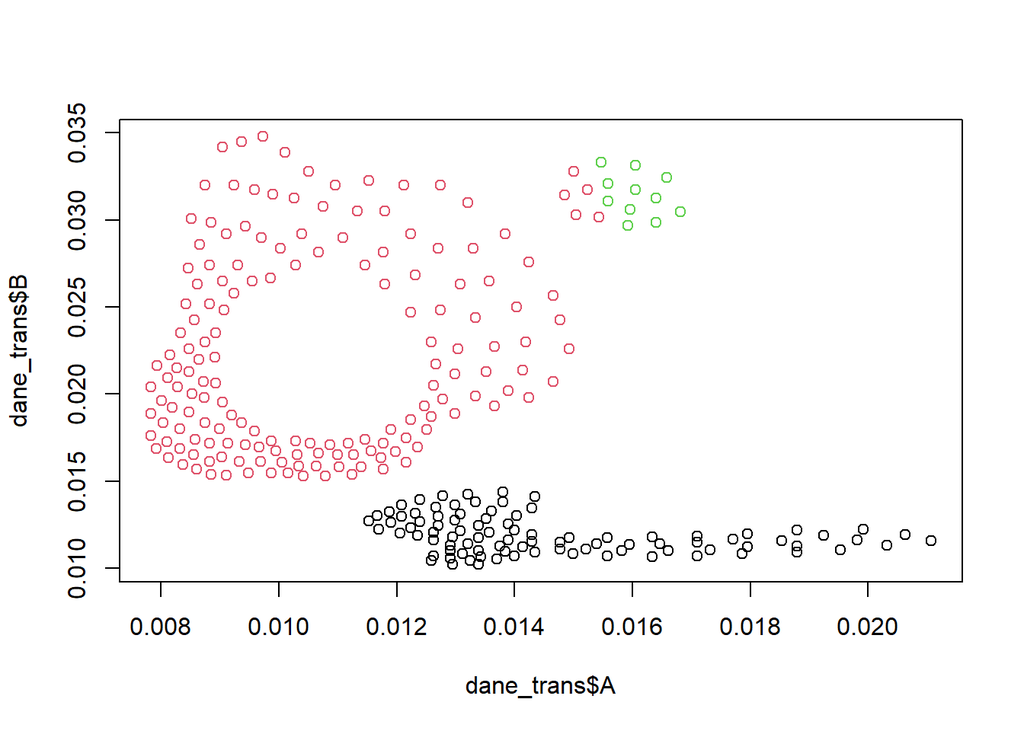

In the penalized logistic regression model, the model was wrong in a few cases.

Let us now perform a logistic regression model on the (non-linear) input data using basis functions.

Let’s create new variables that are explanatory variables in the new model.

```
##         V1       V2       V3       V4       V5       V6
## 1 7.085764 4.332795 1.737287 1.715581 4.306770 7.059272
## 2 7.085339 4.332380 1.736949 1.715947 4.307198 7.059705
## 3 7.085007 4.332073 1.736775 1.716369 4.307604 7.060098
## 4 7.085082 4.332170 1.736954 1.716485 4.307625 7.060095
```

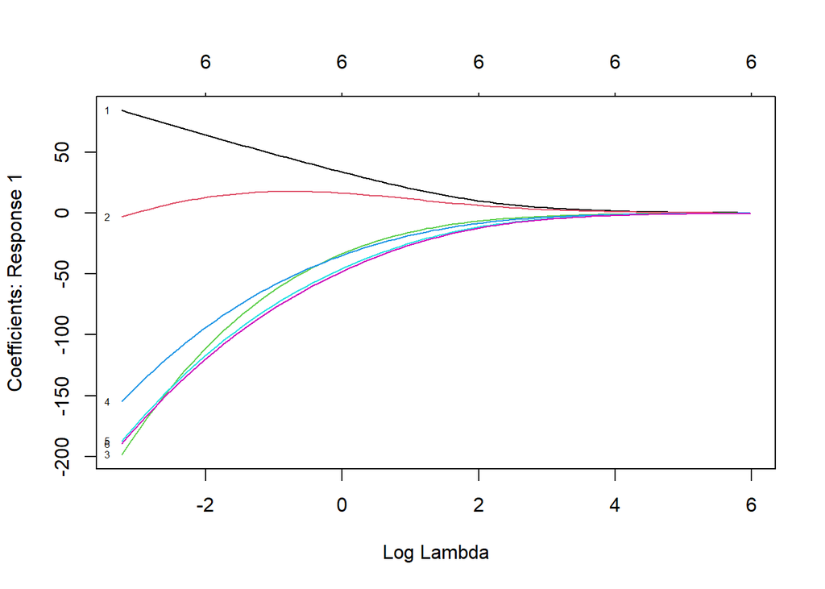

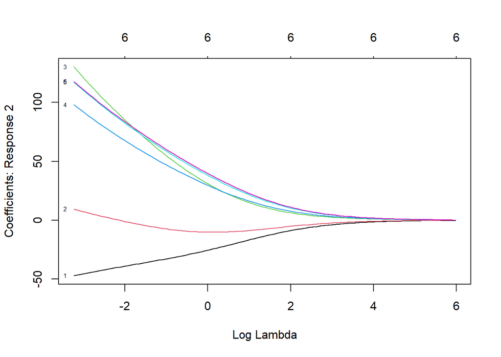

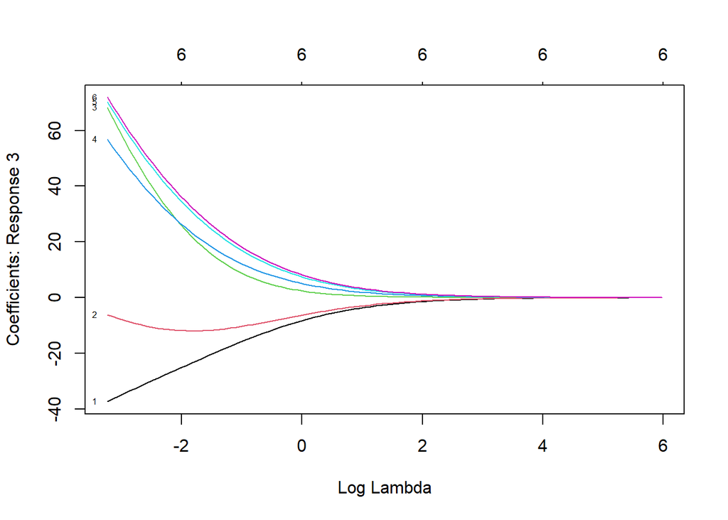

The above plots produce many different coefficients for the model due to the lambda parameter in the ridge regression. The algorithm tested the model on many different lambdas, but placed the logarithm of them on the OX axis. Note that large lambda values cause the coefficients to approach 0. This makes the model unfit. Therefore, we try to choose a smaller lambda in order to create an appropriate model.

We need to choose the best lambda parameter and the most optimized coefficients for our model. For this purpose, we will use cross-validation.

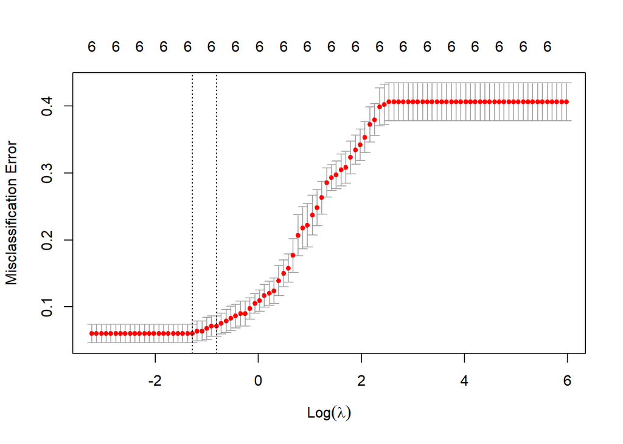

```
##
## Call:  cv.glmnet(x = as.matrix(nowa_ramka[, 1:6]), y = nowa_ramka$Class,      type.measure = "class", nfolds = 10, family = "multinomial",      alpha = 0)
##
## Measure: Misclassification Error
##
##     Lambda Index Measure      SE Nonzero
## min 0.2784    79 0.06015 0.01385       6
## 1se 0.4433    74 0.07143 0.01512       6
```

In the case of the glmnet function, the classification error was only 0.06015 for the lambda determined by the function.

Let’s see what the model looks like for a smaller number of variables resulting from radial functions.

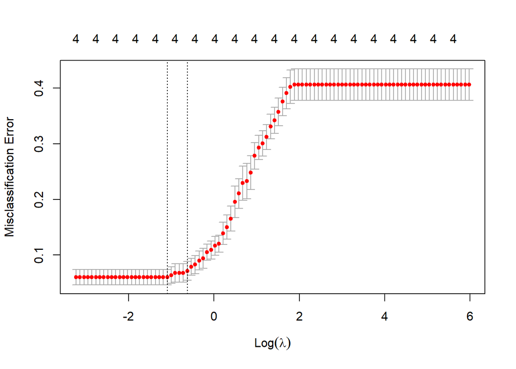

```
##
## Call:  cv.glmnet(x = as.matrix(nowa_ramka2[, 1:4]), y = nowa_ramka$Class,      type.measure = "class", nfolds = 10, family = "multinomial",      alpha = 0)
##
## Measure: Misclassification Error
##
##     Lambda Index Measure      SE Nonzero
## min 0.3350    77 0.06015 0.01385       4
## 1se 0.5334    72 0.07143 0.01703       4
```

Let’s check the classification for another base function

```
## glmnet
##
## 266 samples
##   6 predictor
##   3 classes: '1', '2', '3'
##
## No pre-processing
## Resampling: Cross-Validated (10 fold)
## Summary of sample sizes: 239, 239, 238, 240, 240, 240, ...
## Resampling results across tuning parameters:
##
##   alpha  lambda        Accuracy   Kappa
##   0.10   0.0007902465  0.9401506  0.8786778
##   0.10   0.0079024653  0.9401506  0.8786778
##   0.10   0.0790246526  0.9401506  0.8786778
##   0.55   0.0007902465  0.9401506  0.8786778
##   0.55   0.0079024653  0.9401506  0.8786778
##   0.55   0.0790246526  0.9401506  0.8786778
##   1.00   0.0007902465  0.9401506  0.8786778
##   1.00   0.0079024653  0.9401506  0.8786778
##   1.00   0.0790246526  0.9401506  0.8786778
##
## Accuracy was used to select the optimal model using the largest value.
## The final values used for the model were alpha = 0.1 and lambda = 0.07902465.
```

```
## glmnet
##
## 266 samples
##   4 predictor
##   3 classes: '1', '2', '3'
##
## No pre-processing
## Resampling: Cross-Validated (10 fold)
## Summary of sample sizes: 239, 239, 238, 240, 240, 240, ...
## Resampling results across tuning parameters:
##
##   alpha  lambda        Accuracy   Kappa
##   0.10   0.0007903057  0.9401506  0.8786778
##   0.10   0.0079030567  0.9401506  0.8786778
##   0.10   0.0790305666  0.9401506  0.8786778
##   0.55   0.0007903057  0.9401506  0.8786778
##   0.55   0.0079030567  0.9401506  0.8786778
##   0.55   0.0790305666  0.9328755  0.8633345
##   1.00   0.0007903057  0.9401506  0.8786778
##   1.00   0.0079030567  0.9401506  0.8786778
##   1.00   0.0790305666  0.9328755  0.8633345
##
## Accuracy was used to select the optimal model using the largest value.
## The final values used for the model were alpha = 0.1 and lambda = 0.07903057.
```

For both base functions, the level of correct classification was high. The greatest difficulty for the classifier were observations from class 3, which it was unable to separate from the rest and only for them a classification error occurred.

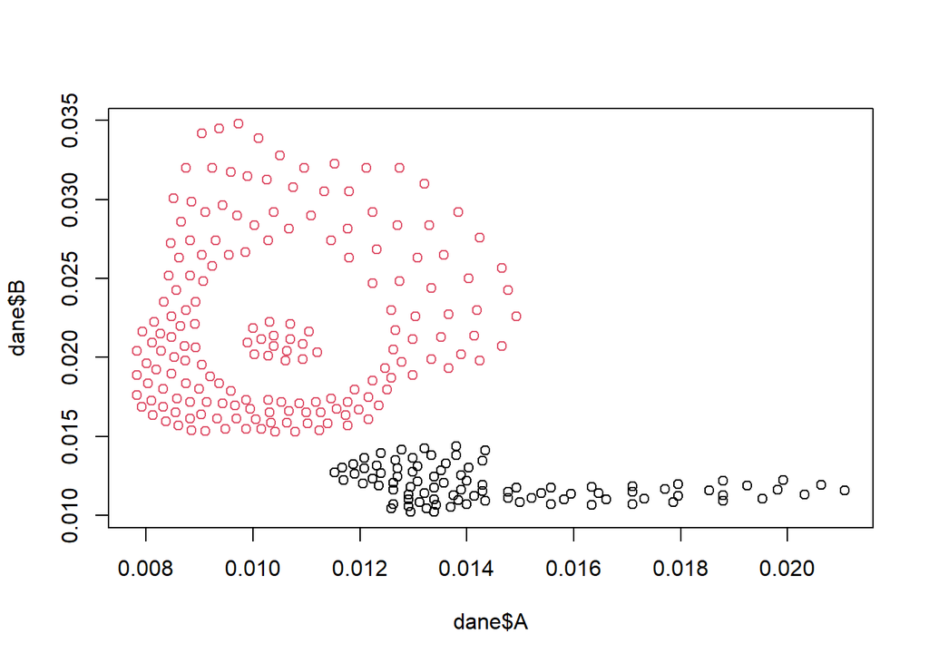

Changes in the l and m_i coefficients only slightly changed the classification areas.